# Impacto del proceso de vacunación contra la Covid-19

Mauricio Rodriguez, Renato Rodriguez, Sebastian Quispe, Christian Salazar, Frings Barrueta

June 11th 2021

# Cargamos librerías

```r
library(readr)
library(dplyr)
```

```r
library(stringr)
library(ggplot2)
library(stringr)
library(scales)
library(lubridate)
library(modeest)
library(viridis)
library(lubridate)
```

# Asignar DF’s con los datos raw de los archivos

```r
DFFallecidosRAW <- read_csv("fallecidos_covid.csv")
DFVacunadosRAW <- read_csv("vacunas_covid.csv")
```

# Asignar DF con las proporciones por departamento

```r
DFProporciones <- read_csv("PoblacionTotal.csv")
```

# Limpieza tabla DFVacunados

# Limpieza tabla DFFallecidos

```r
#suma <- (sum(DFProporciones$POBLACION * 1000))/100
tablaVacunados <- table(DFVacunadosCLEAN$DEPARTAMENTO)

tablaFallecidos <- table(DFFallecidosCLEAN$DEPARTAMENTO)

DFProporciones <-mutate(DFProporciones, porcentajeVacunados = as.double((tablaVacunados[DFProporciones$DEPARTAMENTO])*100/(DFProporciones$POBLACION*1000))/100)

DFProporciones <-mutate(DFProporciones, porcentajeFallecidos = as.double((tablaFallecidos[DFProporciones$DEPARTAMENTO])*100/(DFProporciones$POBLACION*1000))/100)
```

# Análisis descriptivo

## Descriptores Gráficos

### Cantidad de fallecidos por día

Podemos observar claramente cómo han habido dos olas en las que hubo una gran cantidad de fallecidos por día. El gráfico aparenta que el decremento de fallecidos en la segunda ola ha sido más rápido y el número de fallecidos por día ha llegado a niveles inferiores a los de la primera ola. Este descriptor es importante ya que el decremento de fallecimientos de la segunda ola coincide con la llegada de las vacunas al Perú, lo que nos permite estudiar la influencia del proceso de vacunación en el número de fallecimientos.

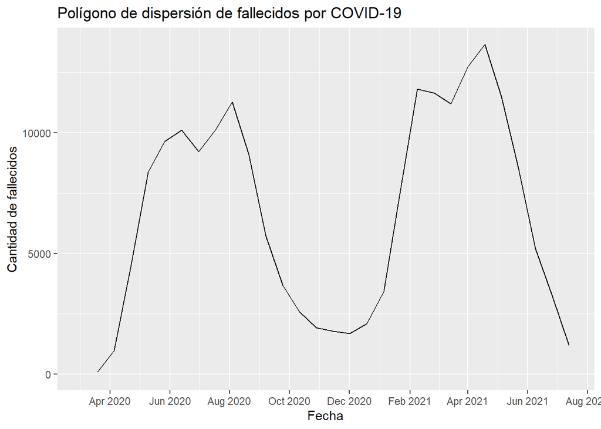

### Edades de personas fallecidas por Covid-19

En el diagrama podemos observar en términos de frecuencia las edades que tenían las personas fallecidas por covid. Se visualiza que las edades de las personas que más han fallecido por la pandemia tenían entre 60 y 75 años. Sin embargo, esto no quita el hecho de que gran cantidad de los fallecidos sean personas mayores de 40 años. Esta gráfica nos permite entender cuáles son los rangos de edades más afectados por covid 19 para de esa forma poder enfocar gran parte del estudio en ese sector.

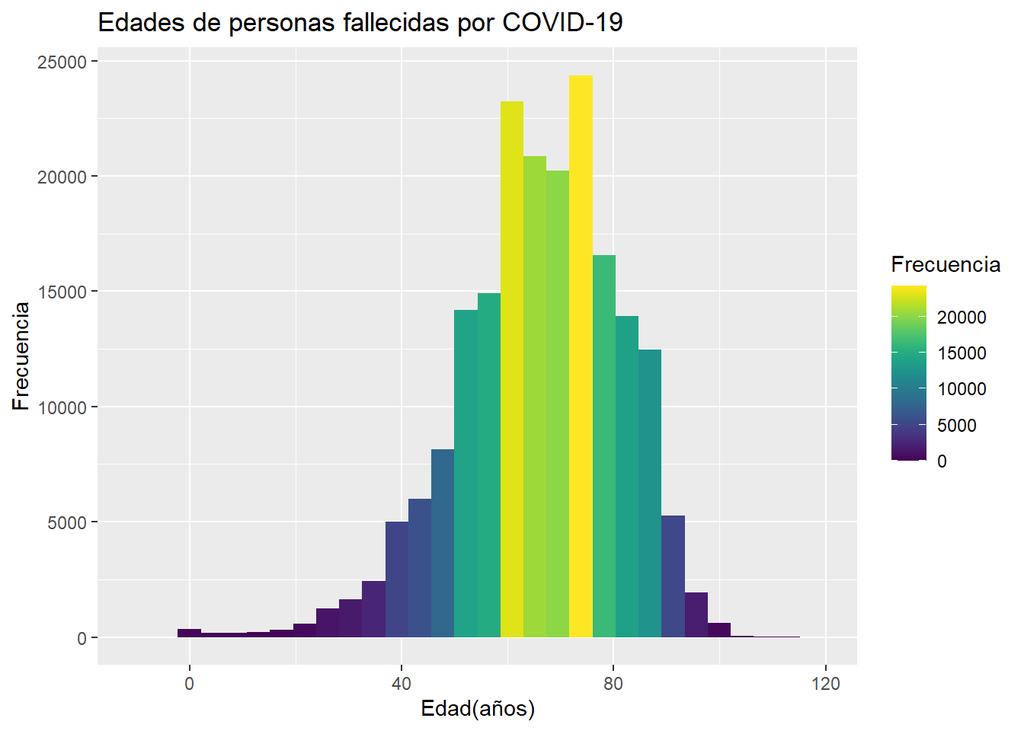

### Edades por día de vacunación

En esta gráfica observamos la edad de personas vacunadas en promedio por día. Podemos ver que al inicio del proceso de vacunación las edades en promedio eran de entre 30 y 55 años aproximadamente, esto se explica porque al inicio del proceso de vacunación se priorizó la inoculación de la vacuna a las personas que se encontraban en la primera línea de emergencia; lo cual abarcaba a doctores, enfermeros, bomberos, militares y policías. Esto ocurrió hasta inicios de abril en donde comenzó terminó la vacunación de personal de primera línea y empezó la vacunación de personas mayores, iniciando con los rangos más altos de edad, para lo cual en mayo se puede observar el pico de promedio de edad más alto registrado. Después de esta fecha el promedio ha decrecido a un ritmo parecido a un modelo lineal, aunque conforme pasa el tiempo, disminuye la edad promedio de fallecidos por día y la pendiente de la gráfica tmb se vuelve menos empinada, esto debido a que conforme la edad promedio de vacunados es menor, existe una mayor cantidad de personas a las cuales vacunar para seguir disminuyendo el promedio.

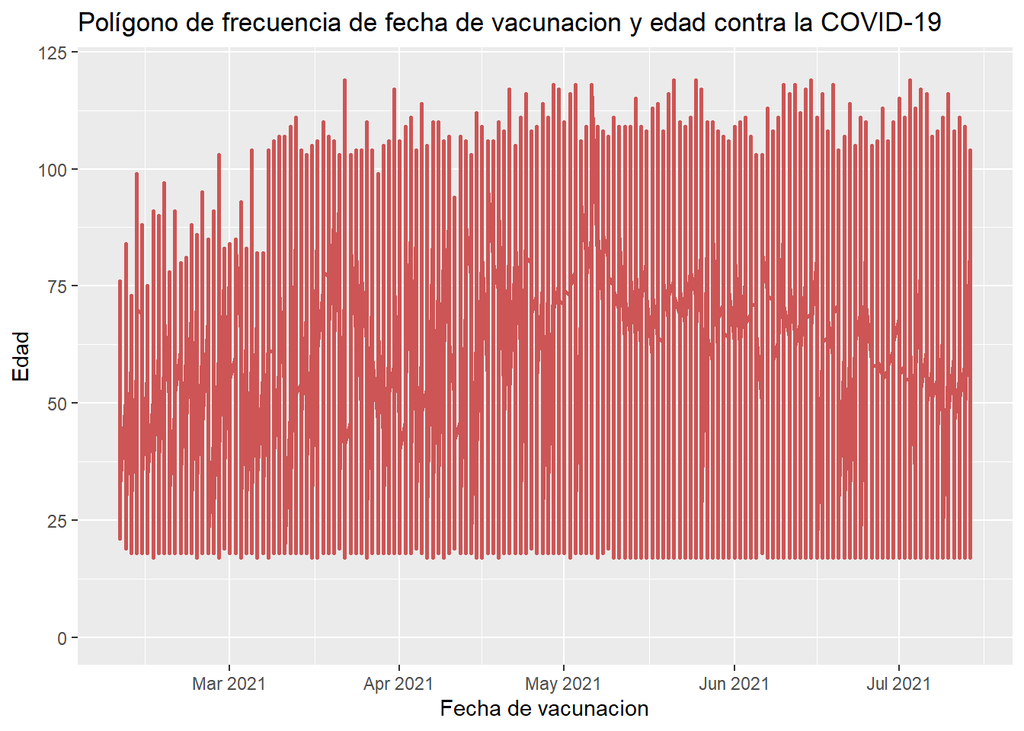

### Sexo de personas fallecidas por Covid-19

En este gráfico se aprecia de forma simple y concisa que la cantidad de personas fallecidas por Covid - 19 han sido en su mayoría hombres, siendo que alrededor de 120,000 decesos ocurridos han sido de hombres mientras que menos de 80,000 fueron de mujeres. Esto es útil para estudiar posteriormente el impacto de la vacunación por sexo en los fallecimientos ya que podría haber distinción de este efecto según el sexo.

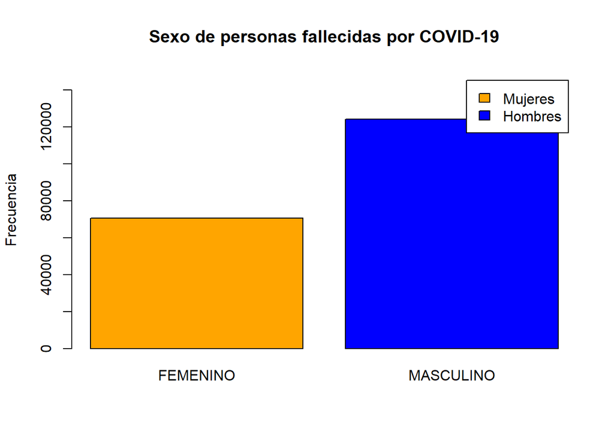

### Porcentaje de fallecidos por departamento en proporción a su cantidad de habitantes

La siguiente gráfica muestra el porcentaje de fallecidos con respecto al tamaño poblacional de cada departamento. Observamos como a pesar de que Lima es la región con mayor cantidad de fallecidos, no es el departamento que se ha visto más afectado en términos de densidad poblacional. Vemos como departamentos como Moquegua, cuya población es significativamente menor posee casi el mismo porcentaje de fallecidos que Lima. Asimismo Ica cuya población es mayor a la de Moquegua pero menor a la de Lima ha sido el departamento más afectado tomando en cuenta el número de víctimas fatales por habitantes. Esta gráfica es importante para nuestro estudio dado que estudiar los fallecimientos únicamente tomando en cuenta las cantidades totales, muestran una falsa impresión de que Lima es el departamento más afectado y con creces. En cambio estudiar los fallecimientos en términos de proporciones por departamento nos permite ver más fácilmente el impacto real de la pandemia en cada uno de ellos.

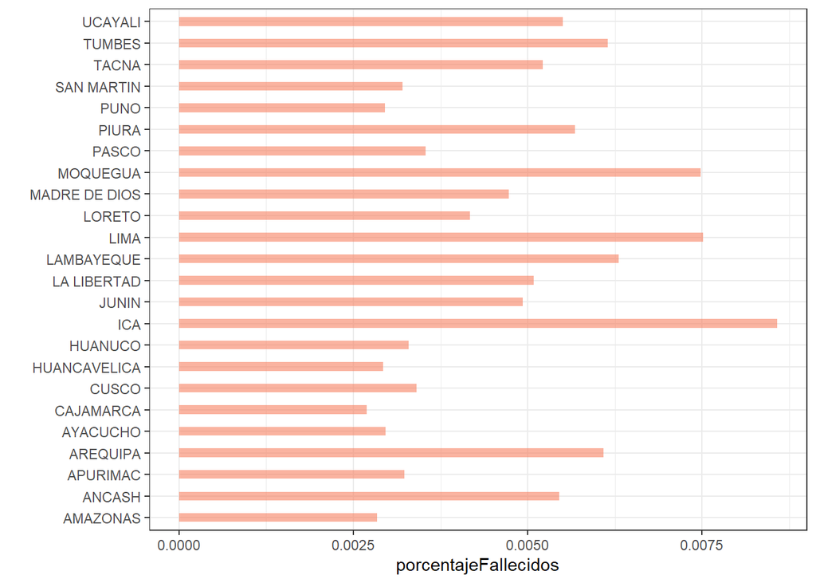

### Cantidad de personas vacunadas por sexo

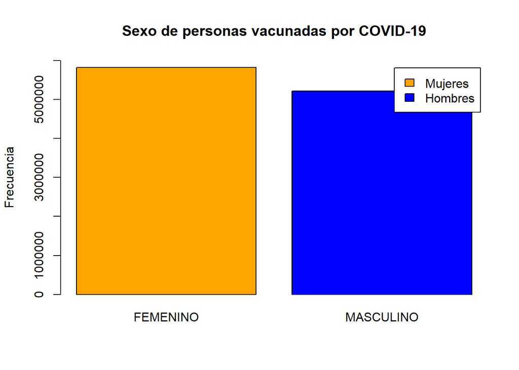

### Cantidad de personas con 1 o 2 dosis

En el gráfico se observa que la cantidad de personas que han recibido una dosis supera a la que han recibido 2, lo que es totalmente normal considerando que existe una diferencia de días que se deben dar para poder aplicarse la segunda dosis. En específico, la cantidad de personas que han recibido una dosis son alrededor de 7 millones mientras que alrededor de 4 millones han recibido ambas dosis, es decir, que el aproximadamente el 36% de la población vacunada cuenta con ambas dosis. Estos datos son útiles para analizar correctamente el impacto de la vacunación según el número de dosis aplicadas.

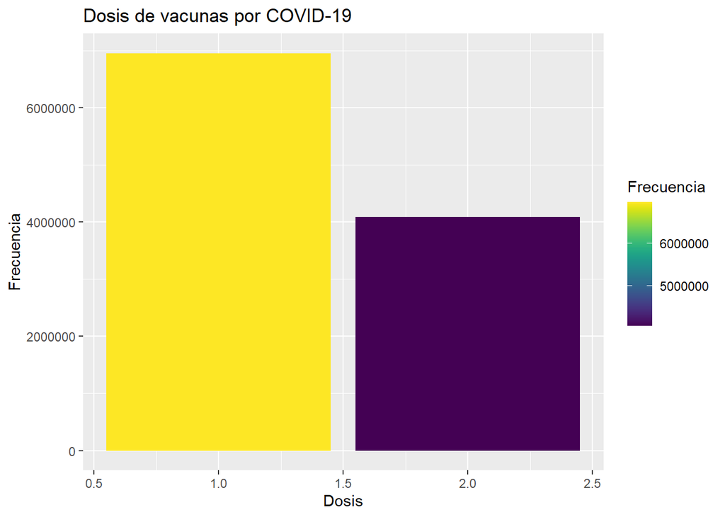

### Cantidad de vacunas inoculadas por fabricante

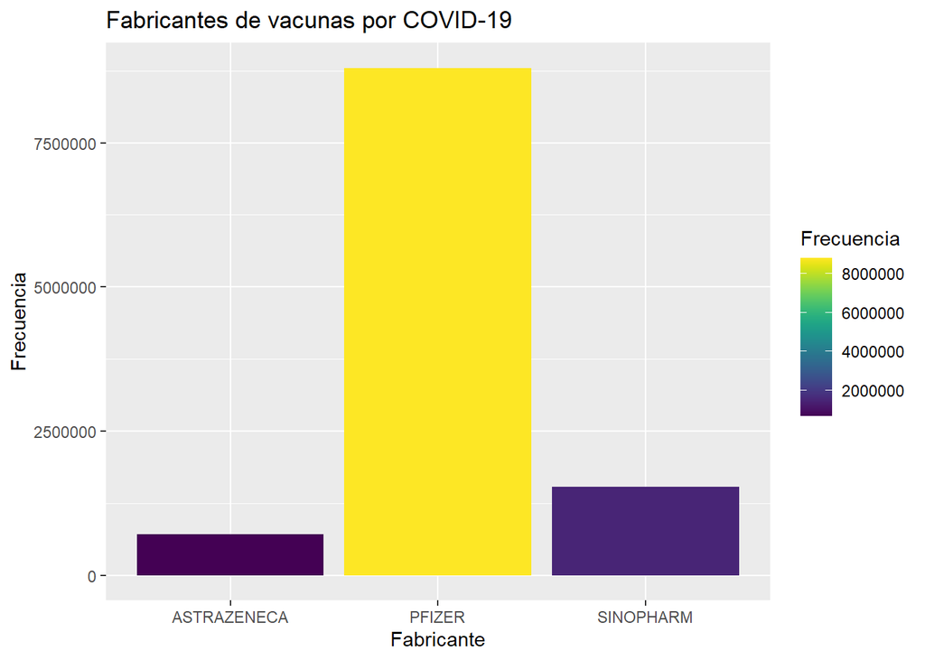

### Porcentaje de vacunados por departamento en proporción a su cantidad de habitantes

En esta gráfica observamos los porcentajes de personas vacunadas por departamento en proporción a su densidad poblacional. Si bien sabemos que Lima es el departamento con el mayor número de vacunados, a nivel de porcentajes es superado por Tacna que ya superó el 50% de población inmunizada. En el caso de Puno observamos que el proceso de vacunación es el más lento a comparación del resto de departamento, con solo el 13% de su población inmunizada. Esta gráfica es importante para nuestro estudio porque observamos que el proceso de vacunación no se está llevando a cabo de manera uniforme con respecto a la densidad poblacional de cada departamento.

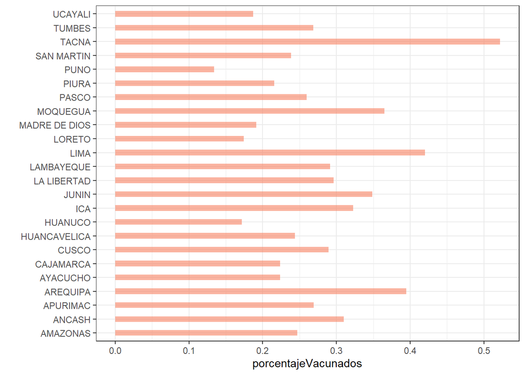

# Numéricas

### Edad promedio de fallecidos por Covid-19

Conocer la edad promedio de los fallecidos por Covid-19 nos ayuda a determinar el grupo de edad el cual concentra una mayor cantidad de personas con consecuencias letales durante la pandemia. En nuestro caso obtuvimos que la edad promedio es 66 años, lo que indica que el sector más afectado por la pandemia son los adultos mayores o de tercera edad. Esta información es útil para nuestro estudio ya que podemos saber cuál fue el sector en el que se debió enfocar la atención y recursos médicos durante la emergencia.

```
## [1] 66
```

### Rango de edad de personas fallecidas a causa de Covid-19

```
## [1] "Edad máxima: 117"
```

```
## [1] "Edad mínima: -9"
```

```
## [1] "Rango: 126"
```

### Edad promedio de vacunados contra Covid-19

La edad promedio de vacunados contra Covid-19 nos indica en qué sector de la población se han realizado la mayor cantidad de vacunas, por ende a cual sector se le ha dado prioridad en esta pandemia. En nuestra muestra la edad promedio de vacunados resultó 60 años, lo que indica que fueron priorizados los adultos mayores en el proceso de vacunación.

```
## [1] 60
```

### Rango de edad de personas vacunadas contra Covid-19

```
## [1] "Edad máxima: 224"
```

```
## [1] "Edad mínima: 17"
```

```
## [1] "Rango: 207"
```

#### Maxima y mínima cantidad de fallecidos

```
## [1] 846
```

```
## [1] 1
```

### Edad máxima y mínima de los fallecidos

```
## [1] 117
```

```
## [1] -9
```

### Mayor y menor cantidad de vacunados en un día

```
## [1] 279826
```

```
## [1] 1
```

# Análisis inferencial

## Es verdad que la media de edad de fallecidos es igual a la de vacunados

- Nivel de confianza: 98%.
- Significancia($\alpha$): 0.02 H0: La media verdadera de la edad de fallecidos es igual a la de vacunados

```r
FC <- DFFallecidosCLEAN$EDAD
V <- DFVacunadosCLEAN$EDAD

t.test(x=FC, y=V, conf.level=0.98)
```

```
##
##  Welch Two Sample t-test
##
## data:  FC and V
## t = 168.07, df = 201908, p-value < 0.00000000000000022
## alternative hypothesis: true difference in means is not equal to 0
## 98 percent confidence interval:
##  5.767614 5.929522
## sample estimates:
## mean of x mean of y
##  66.05640  60.20784
```

En este caso el es menor $p$-value al nivel de significacia $\alpha = 0.02$. Por lo tanto, la hipótesis nula se rechaza. Con un 98% de confianza, podemos decir que la media de edad de fallecidos no es igual a la de vacunados.

## Es verdad que al día el por lo menos 45% de vacunados son adultos mayores, al 95%.

```r
t.test(x = DF_VAC_DIA_ADULMAY$PROPORCION, mu=0.45, alternative = "greater", conf.level = 0.95)
```

```
##
##  One Sample t-test
##
## data:  DF_VAC_DIA_ADULMAY$PROPORCION
## t = 1.1102, df = 161, p-value = 0.1343
## alternative hypothesis: true mean is greater than 0.45
## 95 percent confidence interval:
##  0.435932      Inf
## sample estimates:
## mean of x
## 0.4787037
```

## Es cierto que al día Lima tiene por lo menos 50% de los vacunados

```r
t.test(x = DF_VAC_LIMA$PROPORCION, mu=0.50, alternative = "greater", conf.level = 0.95)
```

```
##
##  One Sample t-test
##
## data:  DF_VAC_LIMA$PROPORCION
## t = -1.1847, df = 162, p-value = 0.8811
## alternative hypothesis: true mean is greater than 0.5
## 95 percent confidence interval:
##  0.45516     Inf
## sample estimates:
## mean of x
## 0.4812883
```

# Relaciones entre variables

## Primera relación

### Cantidad de fallecidos en la 2da ola por etap de vida x Cantidad de vacunados en la 2da ola por etapa de vida

Etapas de vida:

- Niños(0-11 años)
- Adolescentes (12 - 17 años)
- Jóvenes(18 - 29 años)
- Adultos (30 -59 años)
- Adulto Mayor(60 a más)

### Creamos dataset cantidad de fallecidos agrupados por etapa de vida

```r
na.exclude(DFVacunadosCLEAN) %>% mutate(ETAPA = getEtapa(EDAD))%>% group_by(ETAPA,FECHA_VACUNACION) %>% summarize(n = n()) %>% arrange(FECHA_VACUNACION,n)%>% filter(FECHA_VACUNACION>="2021-01-13") -> DFVacEtVida
na.exclude(DFFallecidosCLEAN) %>% mutate(ETAPA= getEtapa(EDAD) ) %>% group_by(ETAPA,FECHA_FALLECIMIENTO) %>% summarize(n = n()) %>%
  arrange(FECHA_FALLECIMIENTO,n) %>% filter(FECHA_FALLECIMIENTO>="2021-01-13") -> DFFallEtVida
```

#### Para adultos mayores

```r
DFFallEtVida %>% filter(ETAPA == "Adulto Mayor") %>%
  filter(FECHA_FALLECIMIENTO >= "2021-02-09" ) -> DFFallAdulMay2daOla
DFVacEtVida %>% filter(ETAPA == "Adulto Mayor") %>%
  filter(FECHA_VACUNACION < "2021-07-15")-> DFVacAdulMay2daOla

DFVacAdulMay2daOla <- mutate(DFVacAdulMay2daOla, frecAcumulativa = cumsum(n))
```

#### Gráfica de regresión lineal Adultos Mayores

La siguiente gráfica nos muestra la regresión lineal para el caso de los adultos mayores durante la segunda ola de la pandemia. En el eje X se encuentra la frecuencia acumulada de adultos mayores vacunados y en el eje Y la cantidad de adultos mayores fallecidos por día. Con esta gráfica observamos que la pendiente de la línea es significativa, lo que indica que existe una relación entre la cantidad de adultos mayores vacunados en total y la cantidad de adultos mayores fallecidos diariamente. Esta relación nos indica que a mayor cantidad de adultos mayores vacunados en total, la cantidad de adultos mayores que fallecen diariamente por Covid-19 disminuye. Cada uno de los puntos de la gráfica de dispersión nos indica un día en el cual son comparados ambos parámetros, estos días avanzan cronológicamente de izquierda a derecha. Esto se puede observar en la gráfica debido a que al inicio de la pandemia la cantidad de adultos mayores vacunados era muy pequeña. Por ello, podemos encontrar una acumulación de puntos en el lado izquierdo de la gráfica por el pequeño aumento de vacunados diarios al inicio de la segunda ola. Por otro lado, en los puntos del extremo derecho de la gráfica observamos que los puntos se encuentran más separados en el eje X. Esta información se traduce como una mayor cantidad de adultos mayores vacunados diariamente.

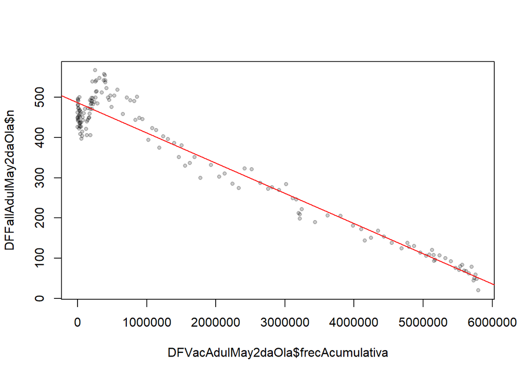

```
##
## Call:
## lm(formula = DFFallAdulMay2daOla$n ~ DFVacAdulMay2daOla$frecAcumulativa)
##
## Residuals:
##    Min     1Q Median     3Q    Max
## -85.19 -28.10  -1.11  19.11 100.40
##
## Coefficients:
##                                         Estimate    Std. Error t value
## (Intercept)                        486.667612995   4.118696738  118.16
## DFVacAdulMay2daOla$frecAcumulativa  -0.000075174   0.000001543  -48.73
##                                               Pr(>|t|)
## (Intercept)                        <0.0000000000000002 ***
## DFVacAdulMay2daOla$frecAcumulativa <0.0000000000000002 ***
## ---
## Signif. codes:  0 '***' 0.001 '**' 0.01 '*' 0.05 '.' 0.1 ' ' 1
##
## Residual standard error: 39.01 on 154 degrees of freedom
## Multiple R-squared:  0.9391, Adjusted R-squared:  0.9387
## F-statistic:  2375 on 1 and 154 DF,  p-value: < 0.00000000000000022
```

#### Para adultos

```r
DFFallEtVida %>% filter(ETAPA == "Adulto") %>%
  filter(FECHA_FALLECIMIENTO >= "2021-02-09" ) -> DFFallAdul2daOla
DFVacEtVida %>% filter(ETAPA == "Adulto") %>%
  filter(FECHA_VACUNACION < "2021-07-14")-> DFVacAdul2daOla

DFVacAdul2daOla <- mutate(DFVacAdul2daOla, frecAcumulativa = cumsum(n))
```

#### Gráfica de regresión lineal Adultos

En la siguiente gráfica se observa el resultado de aplicar el método de regresión lineal, donde los valores del eje Y son la cantidad de adultos fallecidos en la segunda ola, mientras que los valores del eje X son la frecuencia acumulada de personas vacunadas pertenecientes al mismo rango de edad durante la segunda ola. La impresión que nos da la gráfica es que si bien al inicio hubo un periodo en el que la cantidad de adultos que fallecían aumentó considerablemente, luego de ello la tendencia que se marca es que la cantidad de fallecidos, a medida que hay un mayor número de personas vacunadas, disminuya.

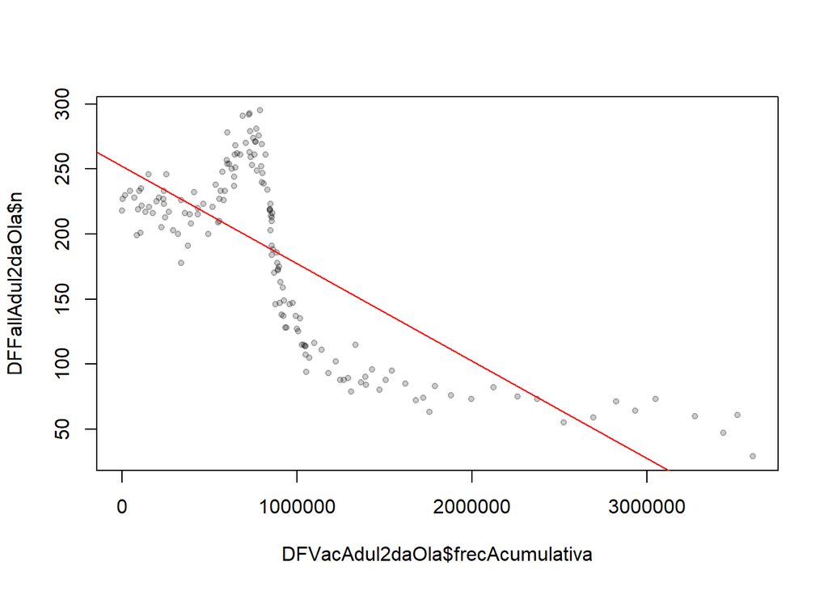

```
##
## Call:
## lm(formula = DFFallAdul2daOla$n ~ DFVacAdul2daOla$frecAcumulativa)
##
## Residuals:
##     Min      1Q  Median      3Q     Max
## -79.321 -37.275  -8.051  39.200 102.027
##
## Coefficients:
##                                      Estimate    Std. Error t value
## (Intercept)                     252.059890314   6.085065401   41.42
## DFVacAdul2daOla$frecAcumulativa  -0.000074883   0.000005226  -14.33
##                                            Pr(>|t|)
## (Intercept)                     <0.0000000000000002 ***
## DFVacAdul2daOla$frecAcumulativa <0.0000000000000002 ***
## ---
## Signif. codes:  0 '***' 0.001 '**' 0.01 '*' 0.05 '.' 0.1 ' ' 1
##
## Residual standard error: 46.3 on 154 degrees of freedom
## Multiple R-squared:  0.5714, Adjusted R-squared:  0.5687
## F-statistic: 205.4 on 1 and 154 DF,  p-value: < 0.00000000000000022
```

#### Para jovenes

```r
DFFallEtVida %>% filter(ETAPA == "Joven") %>%
  filter(FECHA_FALLECIMIENTO >= "2021-02-09" ) -> DFFallJov2daOla
# Limpiamos los datos
s <- as.Date("2021-02-09")
e <- as.Date("2021-07-14")
daysComplete <- seq(from=s, to=e, by=1)
fallComplete <- c()
theDate <- s
while (theDate <= e){
  toSearch <- grep(theDate, DFFallJov2daOla$FECHA_FALLECIMIENTO)
  if(!fun_int0(toSearch)){
    fallComplete <- c(fallComplete, 0)
  } else {
    fallComplete <- c(fallComplete, DFFallJov2daOla$n[toSearch])
  }
  theDate <- theDate + 1
}
# dataset final de vacunados en la segunda ola completo
DFFallJov2daOla <- data.frame(FECHA_FALLECIMIENTO=daysComplete,
                              n=fallComplete)
DFVacEtVida %>% filter(ETAPA == "Joven") %>%
  filter(FECHA_VACUNACION <= "2021-07-14")-> DFVacJov2daOla

DFVacJov2daOla <- mutate(DFVacJov2daOla, frecAcumulativa = cumsum(n))
```

#### Gráfica de regresión lineal Jovenes

En la gráfica mostrada se observa el resultado al aplicar el método de regresión lineal, donde los ejes X e Y representa la frecuencia acumulada de la población joven vacunada durante la segunda ola y la cantidad de personas fallecidas pertenecientes a ese rango, respectivamente. Al visualizar los puntos en la gráfica, que representan los días de la segunda ola, podemos atestiguar la estrategia de vacunación utilizada por el Estado donde la población de primera línea era prioridad y mayoritariamente este rango poblacional no pertenece a la misma, por lo que los puntos se encuentran dispersos y da la impresión que existe un relación baja entre ambos ejes evaluados, esto se da debido a que la región poblacional analizada no ha sido prioridad en el proceso de vacunación en el caso de no poseer ninguna comorbilidad o ser parte de un grupo de riesgo.

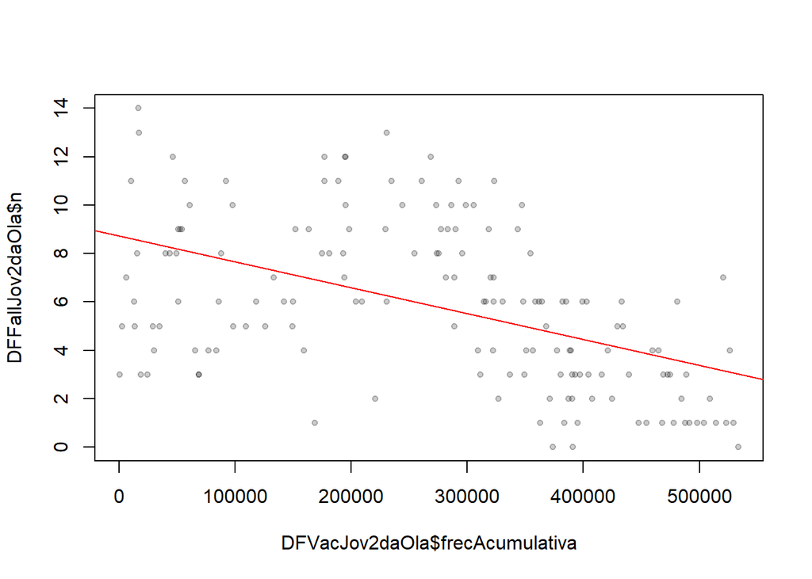

```
##
## Call:
## lm(formula = DFFallJov2daOla$n ~ DFVacJov2daOla$frecAcumulativa)
##
## Residuals:
##     Min      1Q  Median      3Q     Max
## -5.9261 -2.3478 -0.3017  2.0018  6.7405
##
## Coefficients:
##                                    Estimate   Std. Error t value
## (Intercept)                     8.725409119  0.473555112  18.425
## DFVacJov2daOla$frecAcumulativa -0.000010688  0.000001517  -7.046
##                                            Pr(>|t|)
## (Intercept)                    < 0.0000000000000002 ***
## DFVacJov2daOla$frecAcumulativa      0.0000000000577 ***
## ---
## Signif. codes:  0 '***' 0.001 '**' 0.01 '*' 0.05 '.' 0.1 ' ' 1
##
## Residual standard error: 2.93 on 154 degrees of freedom
## Multiple R-squared:  0.2438, Adjusted R-squared:  0.2389
## F-statistic: 49.65 on 1 and 154 DF,  p-value: 0.00000000005772
```

## Segunda relación

### Cantidad de fallecidos por departamento en la 2da ola x Cantidad de vacunados por departamento en la 2da ola en el departamento con más vacunados

Calculamos las regiones más vacunados

```
##
##      AMAZONAS        ANCASH      APURIMAC      AREQUIPA      AYACUCHO
##        103553        370198        120521        602201        152258
##     CAJAMARCA        CALLAO         CUSCO  HUANCAVELICA       HUANUCO
##        331310        585332        386866         93475        137226
##           ICA         JUNIN   LA LIBERTAD    LAMBAYEQUE          LIMA
##        303235        480674        582128        385477       4868067
##        LORETO MADRE DE DIOS      MOQUEGUA         PASCO         PIURA
##        170971         30087         70342         73109        443020
##          PUNO    SAN MARTIN         TACNA        TUMBES       UCAYALI
##        173975        215107        190109         66982        103182
```

```
## LIMA
##   15
```

Vemos que Lima es el departamento que tiene más vacunados, y Madre de Dios es que el tiene menos vacunados.

#### Para Lima

```r
# Calculamos fallecidos por departamento
DFFallecidosCLEAN %>% select(DEPARTAMENTO, FECHA_FALLECIMIENTO) %>%
  filter(DEPARTAMENTO =="LIMA") %>%
  filter(FECHA_FALLECIMIENTO >= as.Date("2021-02-09")) -> fall2daOlaLima
DFfall2daOlaLima <- as.data.frame(table(fall2daOlaLima$FECHA_FALLECIMIENTO),
                              col.names = c("FECHAS", "CANT_FALLECIDOS"))
# Calculamos vacunados por departamento
DFVacunadosCLEAN %>% select(DEPARTAMENTO, FECHA_VACUNACION) %>%
  filter(DEPARTAMENTO =="LIMA") %>%
  filter(FECHA_VACUNACION >= as.Date("2021-02-09") &
         FECHA_VACUNACION <= as.Date("2021-07-14")) -> vac2daOlaLima
DFvac2daOlaLima <- as.data.frame(table(vac2daOlaLima$FECHA_VACUNACION),
                              col.names = c("FECHAS", "CANT_VACUNADOS"))

DFvac2daOlaLima <- mutate(DFvac2daOlaLima, frecAcumulativa = cumsum(Freq))
```

#### Gráfica de regresión Vacunados y Fallecidos en Lima

En la siguiente gráfica tenemos la comparación entre la cantidad total de personas vacunadas en Lima y la cantidad de personas fallecidas por día en Lima durante la segunda ola de la pandemia. Como podemos observar existe una relación ya que la pendiente de la línea de mínimos cuadrados es importante. Esto significa que a mayor cantidad de vacunados totales en Lima, el número de personas fallecidas diariamente se redujo.

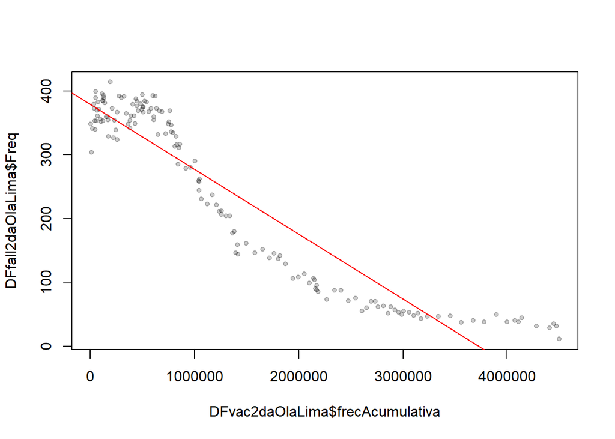

```
##
## Call:
## lm(formula = DFfall2daOlaLima$Freq ~ DFvac2daOlaLima$frecAcumulativa)
##
## Residuals:
##    Min     1Q Median     3Q    Max
## -91.11 -37.12  -2.28  38.37 108.72
##
## Coefficients:
##                                      Estimate    Std. Error t value
## (Intercept)                     379.218387164   5.529428355   68.58
## DFvac2daOlaLima$frecAcumulativa  -0.000101842   0.000002992  -34.04
##                                            Pr(>|t|)
## (Intercept)                     <0.0000000000000002 ***
## DFvac2daOlaLima$frecAcumulativa <0.0000000000000002 ***
## ---
## Signif. codes:  0 '***' 0.001 '**' 0.01 '*' 0.05 '.' 0.1 ' ' 1
##
## Residual standard error: 46.8 on 154 degrees of freedom
## Multiple R-squared:  0.8827, Adjusted R-squared:  0.8819
## F-statistic:  1158 on 1 and 154 DF,  p-value: < 0.00000000000000022
```

## Tercera relación

### Cantidad de fallecidos por departamento en la 2da ola x Cantidad de vacunados por departamento en la 2da ola en el departamento con menos vacunados

```r
table(DFVacunadosCLEAN$DEPARTAMENTO)
```

```
##
##      AMAZONAS        ANCASH      APURIMAC      AREQUIPA      AYACUCHO
##        103553        370198        120521        602201        152258
##     CAJAMARCA        CALLAO         CUSCO  HUANCAVELICA       HUANUCO
##        331310        585332        386866         93475        137226
##           ICA         JUNIN   LA LIBERTAD    LAMBAYEQUE          LIMA
##        303235        480674        582128        385477       4868067
##        LORETO MADRE DE DIOS      MOQUEGUA         PASCO         PIURA
##        170971         30087         70342         73109        443020
##          PUNO    SAN MARTIN         TACNA        TUMBES       UCAYALI
##        173975        215107        190109         66982        103182
```

```r
which.min(table(DFVacunadosCLEAN$DEPARTAMENTO))
```

```
## MADRE DE DIOS
##            17
```

Vemos que Madre de Dios es el departamento que menos vacunados.

#### Gráfica de regresión Vacunados y Fallecidos en Madre De Dios

En esta gráfica de regresión lineal observamos la comparación entre la cantidad total de personas vacunadas en Madre De Dios y la cantidad de personas fallecidas en Madre De Dios por día. La gráfica nos muestra una gran cantidad de puntos dispersos, principalmente al inicio del proceso de vacunación, lo cual dificulta encontrar una gráfica ideal de mínimos cuadrados. A pesar de ello obtenemos en el modelo lineal una pendiente negativa, lo que indica que a mayor número de personas vacunadas en Madre De Dios, disminuye la cantidad de personas fallecidas por día en este departamento.

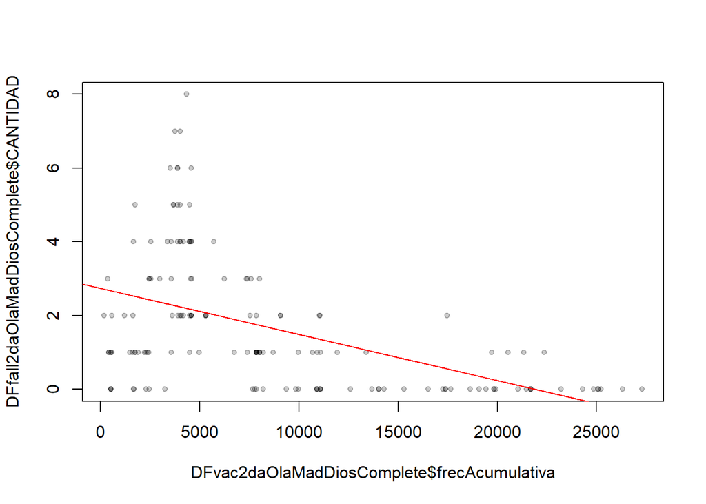

```
##
## Call:
## lm(formula = DFfall2daOlaMadDiosComplete$CANTIDAD ~ DFvac2daOlaMadDiosComplete$frecAcumulativa)
##
## Residuals:
##     Min      1Q  Median      3Q     Max
## -2.6774 -1.0964 -0.2488  0.7251  5.7997
##
## Coefficients:
##                                              Estimate Std. Error t value
## (Intercept)                                 2.7426037  0.2005888  13.673
## DFvac2daOlaMadDiosComplete$frecAcumulativa -0.0001254  0.0000181  -6.931
##                                                        Pr(>|t|)
## (Intercept)                                < 0.0000000000000002 ***
## DFvac2daOlaMadDiosComplete$frecAcumulativa       0.000000000111 ***
## ---
## Signif. codes:  0 '***' 0.001 '**' 0.01 '*' 0.05 '.' 0.1 ' ' 1
##
## Residual standard error: 1.581 on 152 degrees of freedom
## Multiple R-squared:  0.2401, Adjusted R-squared:  0.2351
## F-statistic: 48.04 on 1 and 152 DF,  p-value: 0.0000000001115
```